# Payments by the City and County of San Francisco to Nonprofit Organizations

Author

Don Boyd, Boyd Research LLC

Updated

April 27, 2022

## 1 Highlights

- The City of San Francisco spent approximately $933 million on grants to nonprofit organizations in its 2020-21 fiscal year, according to data from the city controller.
- The top five departments accounted for 89 percent of grants to nonprofits. Three of these departments accounted for more than $100 million each: Human Services ($347 million), Homelessness Services ($271 million), and Children, Youth and Their Families ($110 million).
- The top five nonprofit entities receiving grant payments accounted for 30.8 percent of grants.
- The top three nonprofit recipients of city funds were:
  - The [Children’s Council of San Francisco](https://www.childrenscouncil.org/), which focuses on supporting child care and early childhood education, received $85 million, or 9.1 percent of the total – the most of any nonprofit agency.
  - The [San Francisco In-Home Supportive Services (IHSS) Public Authority](https://www.sfihsspa.org/), a quasi-governmental public agency established by San Francisco ordinance that provides and promotes consumer-directed in-home support, received the next most, at $75 million (8.1 percent).
  - [Episcopal Community Services of San Francisco](https://ecs-sf.org/), which provides support to homeless and very low-income people, received $48 million (5.2 percent).
- More than 540 additional nonprofit organizations received city funds.
- The city controller’s data provides very little information on the uses of these funds. However, individual city departments maintain additional information on the purposes of specific grant funds. The Department of Children, Youth and Their Families provided data on their grant funded programs. These data are included in an accompanying html file and spreadsheet to illustrate the kind of information that may be available from individual agencies.

## 2 Introduction

Nonprofit organizations play an important role in delivering services and helping the needy in San Francisco. This report presents and analyzes information on the city’s payments to nonprofit organizations for the 2020-21 city fiscal year, ending June 30, 2021.[^1]

The sections below:

- Describe data on payments to nonprofits,
- List the city departments with greatest payments to nonprofits,
- List the nonprofit organizations that receive the greatest payments,
- Present a cross-tabulation of payments to major nonprofit organizations by major city departments.
- Present selected data provided by the Department of Children, Youth and Their Families (DCYF) from its internal systems, to illustrate the kinds of additional information that may be available from agency-by-agency requests.

A companion html document provides tables on payments by all departments and nonprofit organizations, in a sortable format. That document also illustrates details from one internal agency system. An associated Excel file includes the summary tables from this report plus the detailed tables in the companion html file.

## 3 About the Data

The analysis is based primarily on data maintained centrally by the city controller on payments to external organizations. It also summarizes selected centrally maintained information on contracts. Payments data provide information on actual spending in a specific time period. By contrast, contracts data provide information on planned spending that may occur over multiple years. The city will not necessarily spend the full amount of the contract.

Individual departments maintain more-detailed data on payments and contracts than data available centrally from the controller. Departments use these data for planning and management purposes.

The city publishes its centrally maintained payments data through two main mechanisms. The [Open Book](https://openbook-report.sfgov.org/OBMiddleware/report.aspx) portal allows creation of user-friendly reports filtered to restrict the data to specific time periods, departments, and other subsets; it allows downloads of potentially large amounts of data but is not designed primarily for that purpose. The [Open Data](https://data.sfgov.org/) portal provides for bulk downloads of large data files and other information in computer-friendly formats. While the two publishing mechanisms draw on similar data, the data elements included and time periods covered may differ between *Open Book* and *Open Data*.[^2]

The city publishes data on payments to external organizations in the [Vendor Payments file](https://data.sfgov.org/City-Management-and-Ethics/Vendor-Payments-Vouchers-/n9pm-xkyq) on *Open Data* and makes similar user-friendly data available through a [Supplier Payments report](https://openbook-report.sfgov.org/OBMiddleware/report.aspx?reportname=5) on *Open Book*. This is the primary source of data used in this report. The city publishes *contracts* data through the [Supplier Contracts file](https://data.sfgov.org/City-Management-and-Ethics/Supplier-Contracts/cqi5-hm2d) on *Open Data* and makes the user-friendly version available through a [Supplier Contracts report](https://openbook-report.sfgov.org/OBMiddleware/report.aspx?reportname=4) on *Open Book*. The *Open Book* version of the data is more current and is the basis for this report.

In addition to data that the city maintains centrally, individual agencies maintain more-detailed data. The Department of Children, Youth and Their Families, which has significant contracts with nonprofit organizations, provided detailed information on the funding allocations they make to nonprofit organizations.

A nonprofit entity [as the city defines it](https://sfgov.org/cmd/sites/default/files/FileCenter/Documents/9818-NPE%20Certification.pdf) in these data must be a 501(c)(3) organization or similar entity, and must have a primary place of business that is a fixed office in San Francisco.

This report focuses on grants to nonprofit organizations, rather than all payments to nonprofits.

## 4 City Departments with the Greatest Payments to Nonprofits

The following table lists the city departments with the greatest payments to nonprofit organizations in 2020-21. The department names are presented as they are listed in the data file; in some cases, they clearly have been abbreviated.

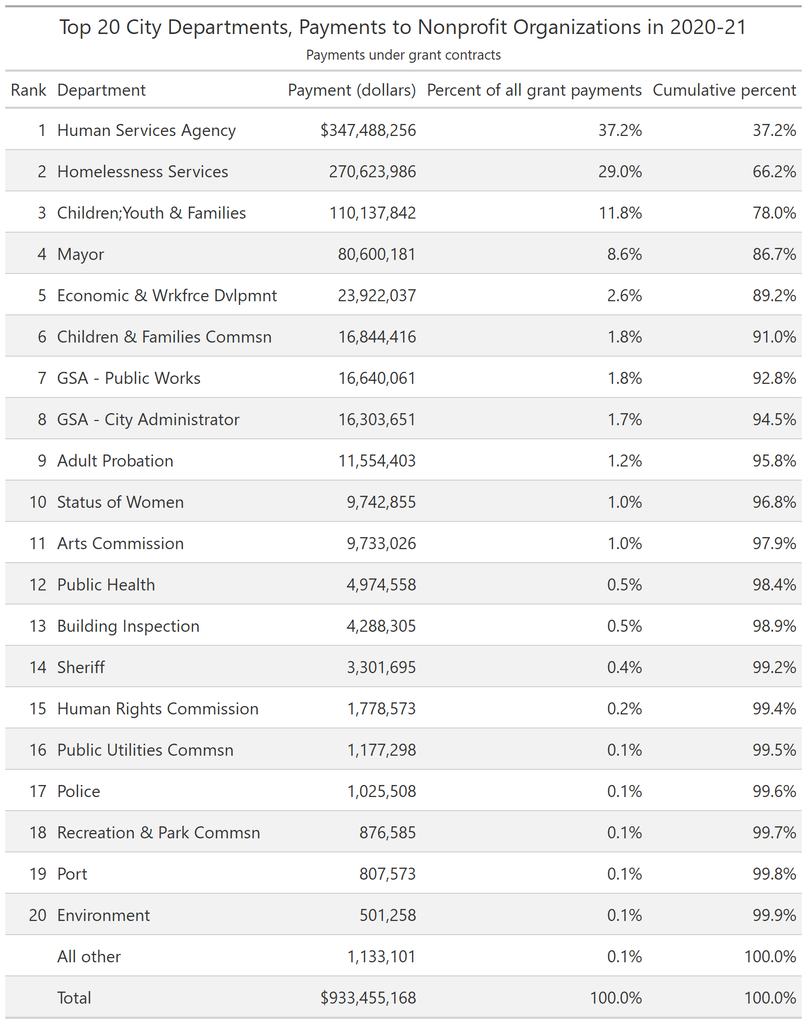

## 5 Nonprofit Organizations That Receive the Greatest Payments

The following table lists nonprofit organizations with the greatest payments from the city in 2020-21. The organization names are presented as they are listed in the data file; in some cases, they clearly have been abbreviated.

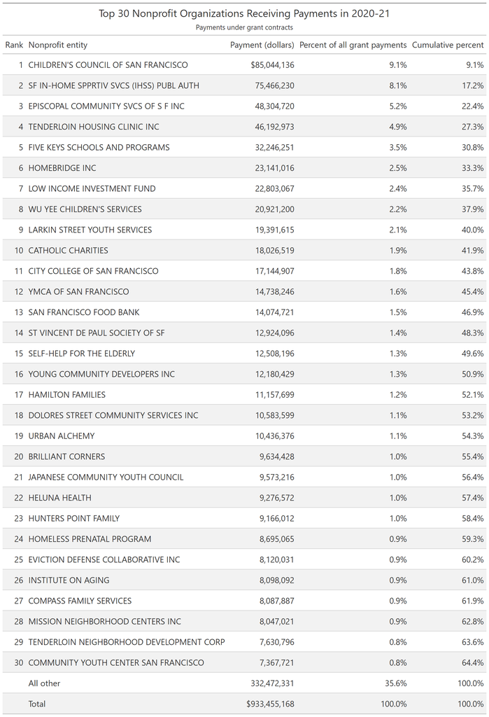

## 6 NonProfit Organizations with the Largest Grant Payments, by Department

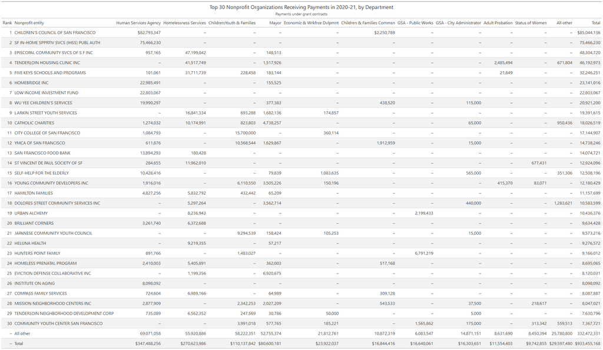

## 7 Appendix

### 7.1 All Nonprofit Organizations and All Departments

| nperank | supplier | Human Services Agency | Homelessness Services | Children;Youth & Families | Mayor | Economic & Wrkfrce Dvlpmnt | Children & Families Commsn | GSA - Public Works | GSA - City Administrator | Adult Probation | Status of Women | Arts Commission | Public Health | Building Inspection | Sheriff | Human Rights Commission | Public Utilities Commsn | Police | Recreation & Park Commsn | Port | Environment | GSA - Technology | Public Library | Elections | City Planning | Emergency Management | Total |
| --- | --- | --- | --- | --- | --- | --- | --- | --- | --- | --- | --- | --- | --- | --- | --- | --- | --- | --- | --- | --- | --- | --- | --- | --- | --- | --- | --- |
| 1 | CHILDREN'S COUNCIL OF SAN FRANCISCO | 82793347 |  |  |  |  | 2250789 |  |  |  |  |  |  |  |  |  |  |  |  |  |  |  |  |  |  |  | 85044136 |
| 2 | SF IN-HOME SPPRTIV SVCS (IHSS) PUBL AUTH | 75466230 |  |  |  |  |  |  |  |  |  |  |  |  |  |  |  |  |  |  |  |  |  |  |  |  | 75466230 |
| 3 | EPISCOPAL COMMUNITY SVCS OF S F INC | 957165 | 47199042 |  | 148513 |  |  |  |  |  |  |  |  |  |  |  |  |  |  |  |  |  |  |  |  |  | 48304720 |
| 4 | TENDERLOIN HOUSING CLINIC INC |  | 41517749 |  | 1517926 |  |  |  |  | 2485494 |  |  |  | 671804 |  |  |  |  |  |  |  |  |  |  |  |  | 46192973 |
| 5 | FIVE KEYS SCHOOLS AND PROGRAMS | 101061 | 31711739 | 228458 | 183144 |  |  |  |  | 21849 |  |  |  |  |  |  |  |  |  |  |  |  |  |  |  |  | 32246251 |
| 6 | HOMEBRIDGE INC | 22985491 |  |  | 155525 |  |  |  |  |  |  |  |  |  |  |  |  |  |  |  |  |  |  |  |  |  | 23141016 |
| 7 | LOW INCOME INVESTMENT FUND | 22803067 |  |  |  |  |  |  |  |  |  |  |  |  |  |  |  |  |  |  |  |  |  |  |  |  | 22803067 |
| 8 | WU YEE CHILDREN'S SERVICES | 19990297 |  |  | 377383 |  | 438520 |  | 115000 |  |  |  |  |  |  |  |  |  |  |  |  |  |  |  |  |  | 20921200 |
| 9 | LARKIN STREET YOUTH SERVICES |  | 16841334 | 693288 | 1682136 | 174857 |  |  |  |  |  |  |  |  |  |  |  |  |  |  |  |  |  |  |  |  | 19391615 |
| 10 | CATHOLIC CHARITIES | 1274032 | 10174991 | 823803 | 4738257 |  |  |  | 65000 |  |  |  | 950436 |  |  |  |  |  |  |  |  |  |  |  |  |  | 18026519 |

[output cut: 538 more lines]

### 7.2 Department of Children, Youth and Their Families Data

The table below shows grant allocations for 2020-21 and 2021-22, by program, provided by the Department of Children, Youth and Their Familes. Grant allocations provide information on expected or planned spending, rather than actual spending, and thus will differ in amounts from numbers in other tables, which are based on actual spending.

| id | agency | program | service area | strategy | description | 2020-21 | 2021-22 |
| --- | --- | --- | --- | --- | --- | --- | --- |
| 1 | 826 Valencia | 826 Valencia After-School Literacy Program at Buena Vista Horace Mann K-8 | Educational Supports | Literacy Supports | 826 Valencia After-School Literacy Program at Buena Vista Horace Mann K-8 provides free onsite literacy after school for students in grades 3 - 5 who have a demonstrated need for additional assistance… | 185658 |  |
| 2 | 826 Valencia | Young Author's Publishing Projects | Enrichment, Leadership and Skill Building | Arts and Creative Expression | 826 Valencia's Young Author's Publishing Projects provide opportunities for creativity, academic skill-building, and social emotional learning for cohorts of students who are underperforming academica… | 291748 |  |
| 3 | ABADA-Capoeira San Francisco | ABADA-Capoeira SF Reaching All Youth Project | Enrichment, Leadership and Skill Building | Arts and Creative Expression | The RAY Project connects youth with master-level artists in an effort to preserve the tradition of Capoeira, inspire learning, and build strong characters. Capoeira is a Brazilian art that combines se… | 103968 |  |
| 4 | After School Enrichment Program | McKinley Elementary ExCEL Program | Out of School Time | ExCEL Equitable Access | ASEP’s McKinley Comprehensive Programs consist of 3 core elements, including academic alignment, health &amp; wellness, and arts enrichment. During the school year, students are picked up from day sch… | 14865 |  |
| 5 | After School Enrichment Program | Webster (Daniel) Elementary ExCEL Program | Out of School Time | ExCEL Equitable Access | ASEP’s Daniel-Webster Comprehensive Programs consist of 3 core elements, including academic alignment, health &amp; wellness, and arts enrichment. During the school year, students are picked up from d… | 25315 |  |
| 6 | Aim High for High School | Aim High for High School | Out of School Time | Comprehensive Year-Round and Summer Learning | Aim High provides low-income, first generation middle school students with a free, multi-year summer academic and enrichment program. Since 1986, we have worked to prevent summer learning loss, a prim… | 434490 |  |
| 7 | Alive &amp; Free | Alive &amp; Free Leadership Academy | Educational Supports | Academic Supports | The Alive &amp; Free Leadership Academy serves San Francisco middle and high school youth in grades 6-12 in need of additional academic support, and San Francisco TAY seeking High School Equivalency C… | 159135 |  |
| 8 | America SCORES Bay Area | America SCORES Soccer Program | Enrichment, Leadership and Skill Building | Sports and Physical Activity | America SCORES Bay Area inspires urban youth to lead healthy lives, be engaged students, and have the confidence and character to make a difference in the world. Our Unique Approach - America SCORES p… | 238703 |  |
| 9 | American Conservatory Theater | Intensive Residencies | Enrichment, Leadership and Skill Building | Arts and Creative Expression | A.C.T.'s ACTsmart Intensive Residencies in schools and community programs provide in-depth arts education to marginalized youth at a variety of sites in San Francisco, with a broad focus on providing … | 159135 |  |
| 10 | APA Family Support Services | Visitacion Valley Strong Families Collaborative | Family Empowerment | Family Resource Centers | 26 family resource centers across the city operate under a shared vision built on families who are thriving, connected, and able to support their children's lifelong success. Parents with children of … | 0 |  |

[output cut: 783 more lines]

## Footnotes

[^1]: References to “city” mean the city and county of San Francisco.
[^2]: I brought several such differences to the attention of staff maintaining these data systems and they are working to correct them and develop greater internal consistency. As of this writing, they have not updated their data online to reflect these changes.